# Analysis of Seattle Airbnb Data from 2016

[figure not shown]

Airbnb has released a lot of its data. The data analyzed in this evaluation comes from https://www.kaggle.com/datasets/airbnb/seattle/data and is available in the public domain under CC0.

The evaluation can be viewed:

- without Python code
- with Python code
1. Description of DataFrames and their Columns
2. Are prices dependent on the neighborhood?
3. Is there a dependency of prices on holidays?
4. Do experienced hosts with multiple listings have better ratings?

# First look into the Data

## Description of DataFrames and their Columns

### calendar DataFrame

The table contains information about the availability and prices of Airbnb listings in Seattle for each calendar day in 2016.

### listings DataFrame

The data contains information about Airbnb listings in Seattle. They include details about the listings themselves, such as ID, URL, name, description, location (street, city, state, zip code, coordinates), and type of accommodation (e.g., room or property type, number of bedrooms and beds, amenities, price, and availability). Additionally, there is information about the hosts, such as their ID, name, location, verifications, and ratings. Reviews and feedback on the listings are also captured, including the number of reviews and various rating criteria (e.g., cleanliness, communication). Other columns concern booking conditions and guest requirements.

### reviews DataFrame

The table contains written reviews of the Airbnb listings with the reviewer's ID and a date. No numerical ratings are included.

# Is there a dependency of prices on holidays?

For this analysis, we need to combine the data from the calendar dataframe with the public holiday information for the US state of Washington (WA). We want to compare the prices on all days before a holiday or weekend day with the remaining prices.

Do accommodations become more expensive when you can sleep in the next day?

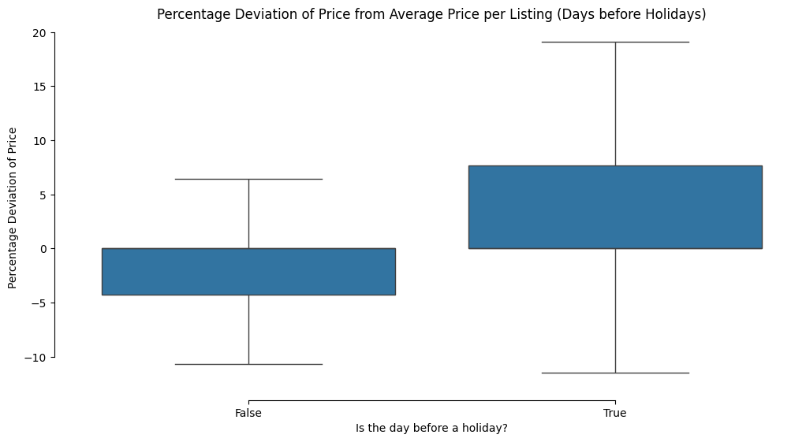

In the chart, you can see that the deviation from the average price (per listing) is significantly higher before a holiday than when the following day is a regular workday.

Before a workday, discounts are common, while before a holiday/weekend, price increases of around 5% are observed.

# Are prices dependent on the neighborhood?

By merging the values from the calendar dataframe and the listings dataframe, we can calculate the average price per neighborhood.

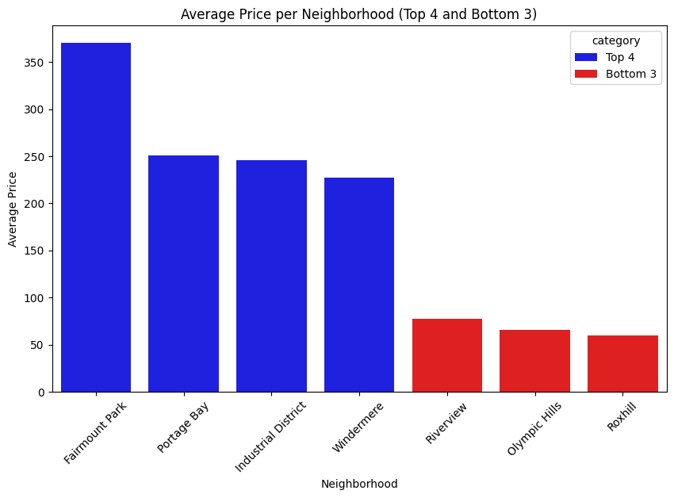

The prices in the different neighborhoods of Seattle vary significantly. By far the most expensive accommodations are in Fairmount Park.

# Do experienced hosts with multiple listings have better ratings?

If hosts offer multiple accommodations, they should be able to gain experience and better tailor the offerings to the needs of visitors.

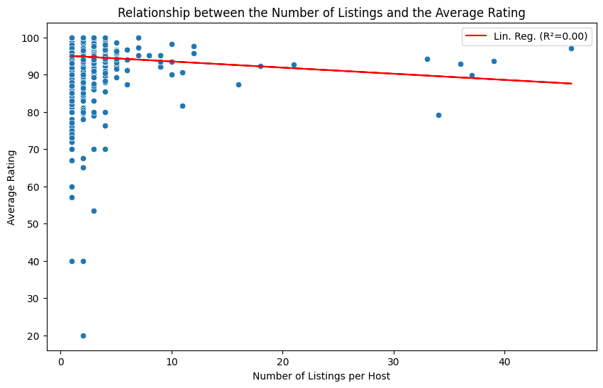

[figure not shown]